# ESTADISTICA PARA EL ANALISIS POLITICO II

- Profesor: [Dr. José Manuel Magallanes, Ph.D.](http://www.pucp.edu.pe/profesor/jose-manuel-magallanes/)
  - Profesor del Departamento de Ciencias Sociales, Sección de Ciencia Política y Gobierno.
  - [Oficina 105](https://goo.gl/maps/xuGeG6o9di1i1y5m6) - Edificio CISEPA / ECONOMIA / CCSS
  - Telefono: (51) 1 - 6262000 anexo 4302
  - Correo Electrónico: jmagallanes@pucp.edu.pe

## Introducción a la Regresión Lineal Multivariada

En esta sesión deseo que entiendas por qué es necesario ir más allá de la correlación (*Pearson*, *Spearman*, etc.) o las diferencias de valores medios (*t test*, *kruska wallis*, etc.) .

Trabajemos con nuestros datos del archivo en SPSS **hsb.sav**:

1. Asumamos que nuestra variable de interés es el desempeño en matemáticas; así, nuestra *variable dependiente* está representada por la variable *MATH*.
2. Consideremos que nos interesa saber la posible relación que pueda tener la variable que ha medido el desempeño en escritura; así una variable independiente sería la representada por la variable *WRTG*. Hasta ahora sabemos que como son *dos* variables de tipo *numérico* debemos usar una correlación. La gráfica de correlación es esta:

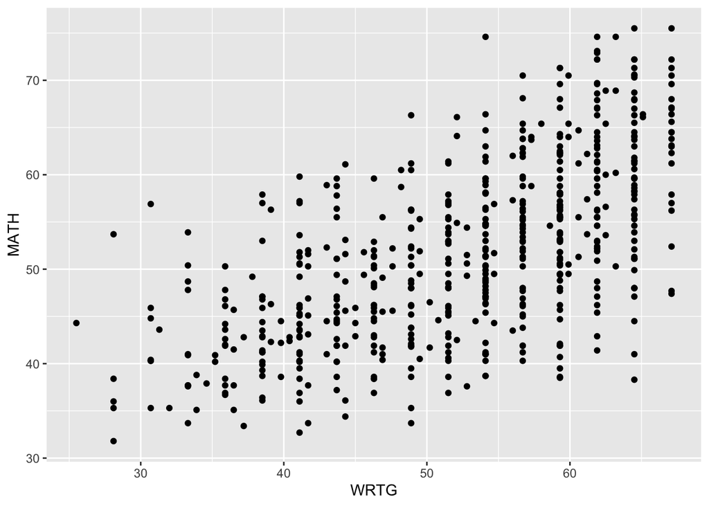

Vemos que hay una aparente relación. Asumiendo un camino paramétrico, podemos pedir el coeficiente de Pearson, el cuál al ser calculado obtenemos 0.6326664 (con p-value= 0). Si hubieramos seguido una ruta no paramétrica, informaríamos el coeficiente de Spearman:0.6415126 (con p-value= 0).

3. Consideremos que nos interesa además saber *a la vez* la posible relación que pueda tener la variable que ha medido el desempeño en ciencias; así otra variable independiente sería la representada por la variable *SCI*. Como es otra variable *numérica* no podemos calcular la correlación de tres variables, pero podemos tratar de verlo visualmente:
- En tres dimensiones:

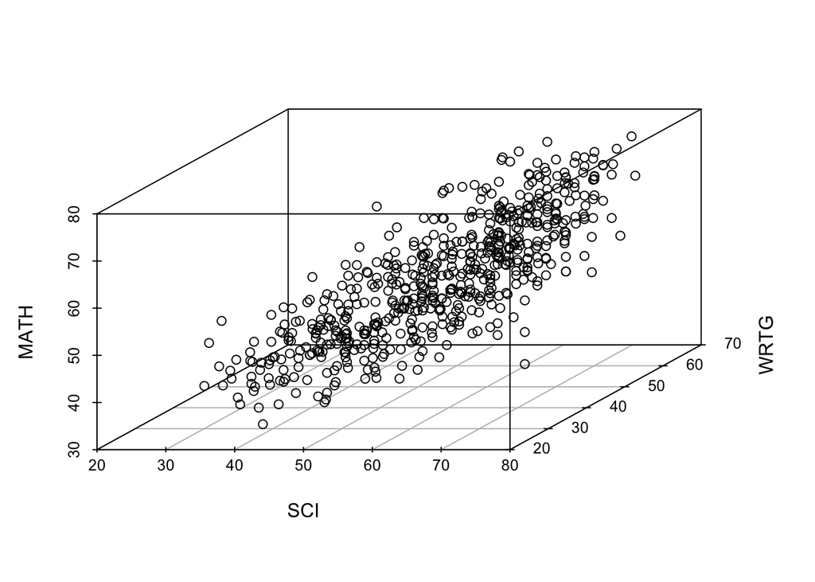

- En dos dimensiones:

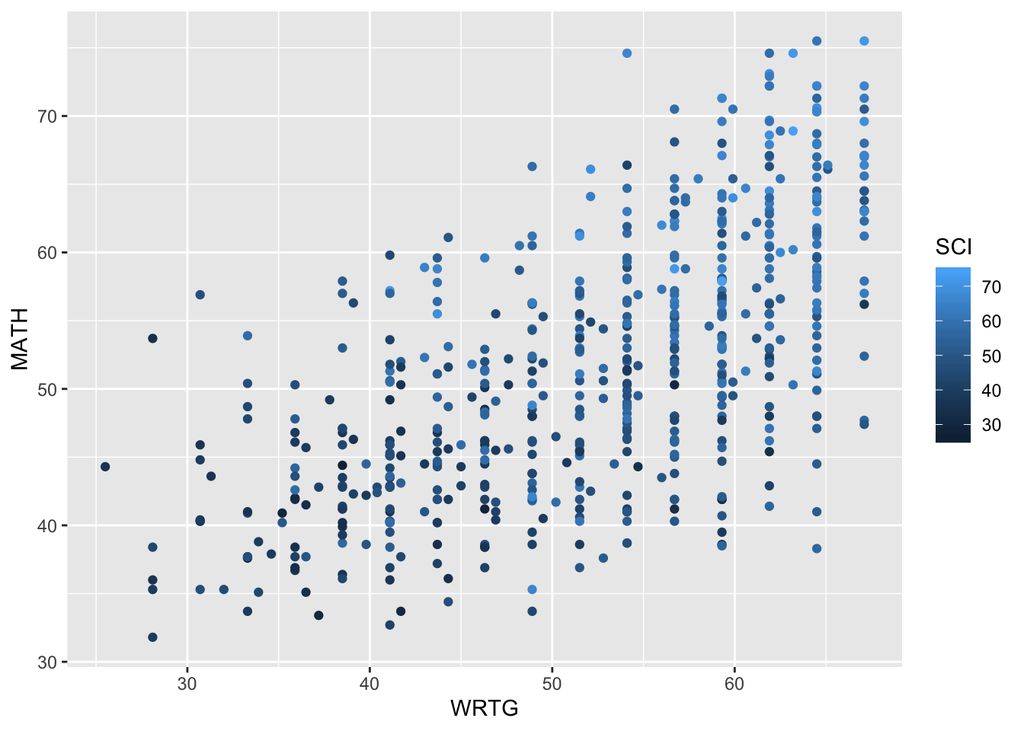

Podríamos calcular la correlación de SCI con MATH, obteniendo el Pearson (0.6495261, p-value= 0) y el Spearman (0.6551515,p-value= 0).

Visualmente vemos relación, pero **no tenemos** un coeficiente para medir ello.

4. Y si quisiéramos ver si el sexo tiene algun rol en todo esto? Como ésta es una variable *categórica* y *dicotómica*, lo primero que puede venir a la mente es esta gráfica:

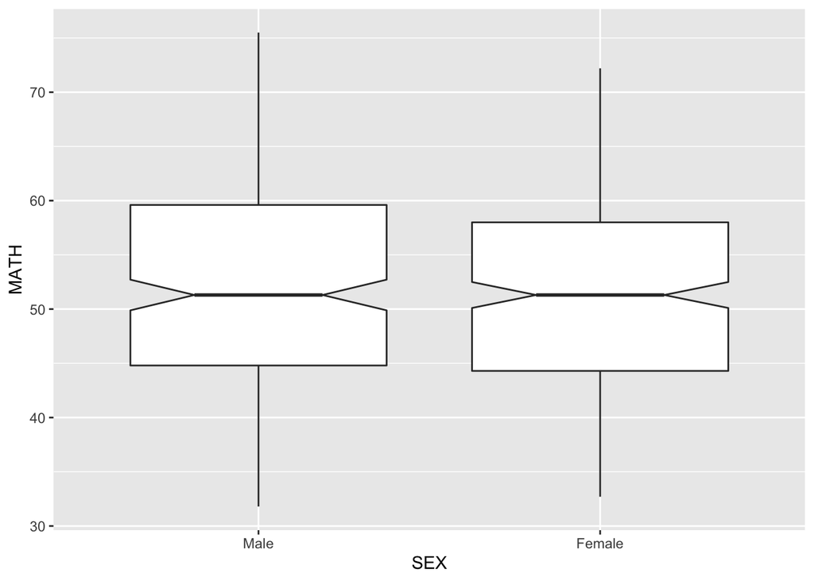

Los boxplots tienen un *notch* flanqueando a la mediana, para sugerir igualdad de medianas si éstos se intersectan; de ahi que parece no haber diferencia sustantiva entre hombres y mujeres en cuanto a su desempeño en MATH.

Este gráfico complementa lo anterior:

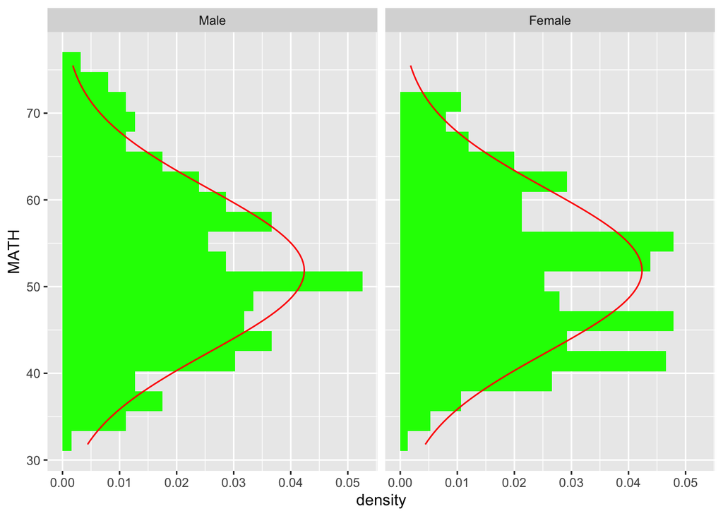

Nota que los histogramas de la data *real* tienen encima la curva *normal* que *idealmente* tendría esa data. La lejanía entre ellos, sugeriría no normalidad. Como ello no es fácil de discernir visualmente, tenemos por costumbre calcular algun coeficiente, como el *Shapiro-Wilk*:

| SEX | W | Prob |
| --- | --- | --- |
| Male | 0.9837903 | 0.0034565 |
| Female | 0.9790040 | 0.0001031 |

Esto nos sugiere un camino no paramétrico para ver la diferencia de valores medios. La prueba no paramétrica no rechazaría la igualdad de valores medios (Mann-Whitney con p valor = 0.3085543).

- Veamos como representar al sexo en nuestra gráfica entre WRTG y MATH:

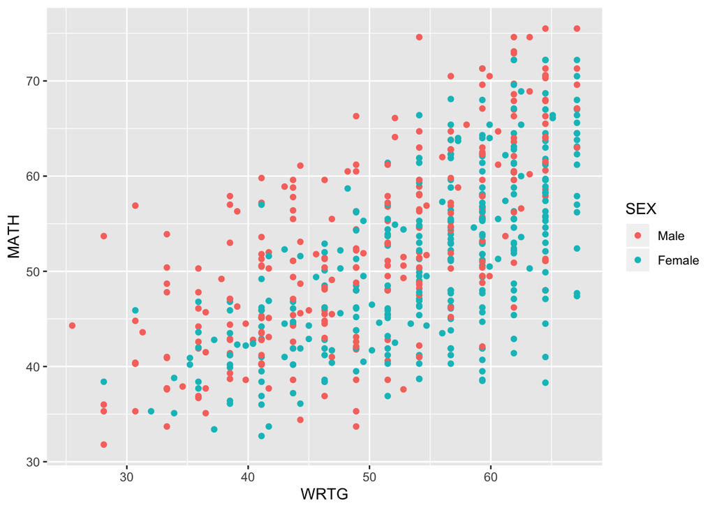

- Veamos como representar al sexo en nuestra gráfica entre WRTG, SCI y MATH:

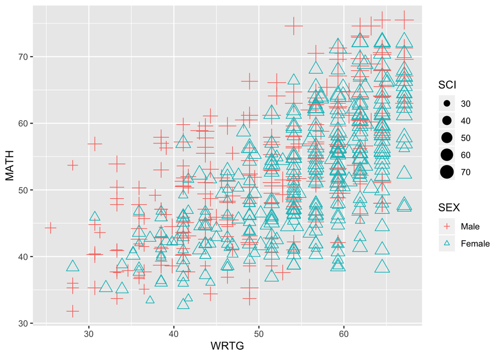

Otra alternativa puede ser:

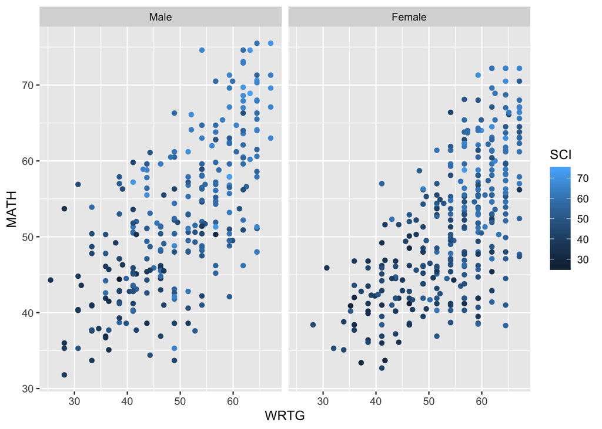

Y claro:

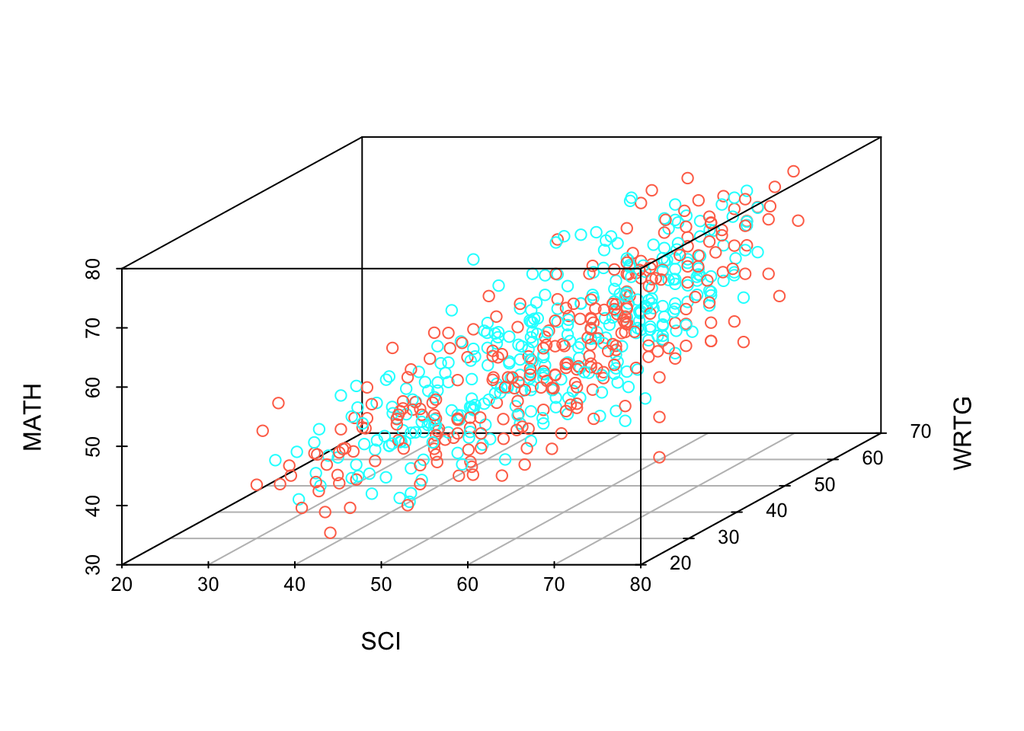

En todos los gráficos vemos que los hombres y las mujeres están distribuidos por todo el gráfico, lo cual nos sugiere que no hay diferencias aun en dimensiones mayores a dos. Sin embargo, no tenemos una medida de cuanto cada uno afecta a nuestra dependiente.

De ahi que necesitamos la **regresión**.

## REGRESIÓN

La regresión sí quiere informar cuánto una variable (*independiente*) puede explicar la variación de otra (*dependiente*), de ahí que es una técnica para probar hipótesis direccionales o asimétricas (las correlaciones tiene hipótesis simétricas).

La regresión busca proponer un modelo, es decir una ecuación, que recoja como una variable explicaría a otra. Por ejemplo, para la hipótesis ‘*el nivel de desempeño en escritura afecta el desempeño en matemáticas*’, la regresión arrojaría este resultado:

|  | *Dependent variable:* |
| --- | --- |
|  | MATH |
| Constant | 19.769*** |
|  | (1.633) |
| WRTG | 0.612*** |
|  | (0.031) |
| Observations | 600 |
| R<sup>2</sup> | 0.400 |
| Adjusted R<sup>2</sup> | 0.399 |
| Residual Std. Error | 7.297 (df = 598) |
| F Statistic | 399.110*** (df = 1; 598) |
| *Note:* | p<0.1; p<0.05; p<0.01 |

Esto es información suficiente para representar esa relación con una ecuación. Como la ecuación sólo tiene una variable independiente podemos producir una recta sobre el gráfico de correlación:

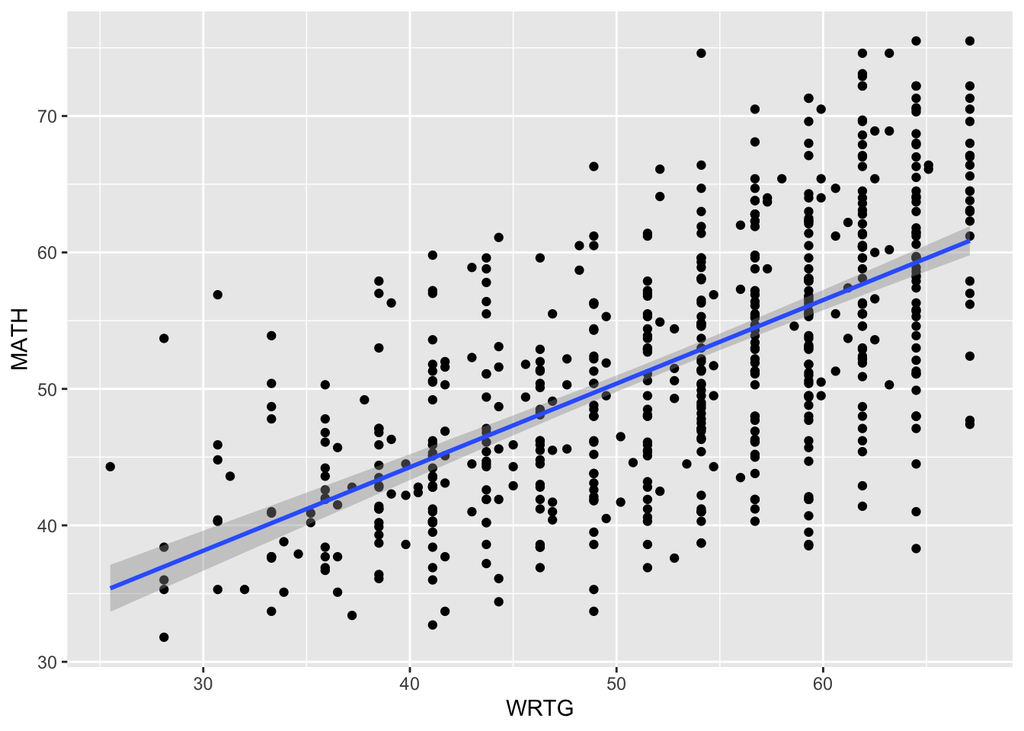

Esa recta podemos representarla así:

$$Y= 19.7690323 + 0.6123904 \cdot WRTG + \epsilon$$

Y sí queremos ver el efecto de SCI?

|  | *Dependent variable:* |
| --- | --- |
|  | MATH |
| Constant | 10.629*** |
|  | (1.630) |
| WRTG | 0.377*** |
|  | (0.033) |
| SCI | 0.415*** |
|  | (0.033) |
| Observations | 600 |
| R<sup>2</sup> | 0.524 |
| Adjusted R<sup>2</sup> | 0.523 |
| Residual Std. Error | 6.505 (df = 597) |
| F Statistic | 328.846*** (df = 2; 597) |
| *Note:* | p<0.1; p<0.05; p<0.01 |

En este caso, la regresión tendrá una formula con dos variables explicando la dependiente, así que en vez de producir una línea buscará producir un plano:

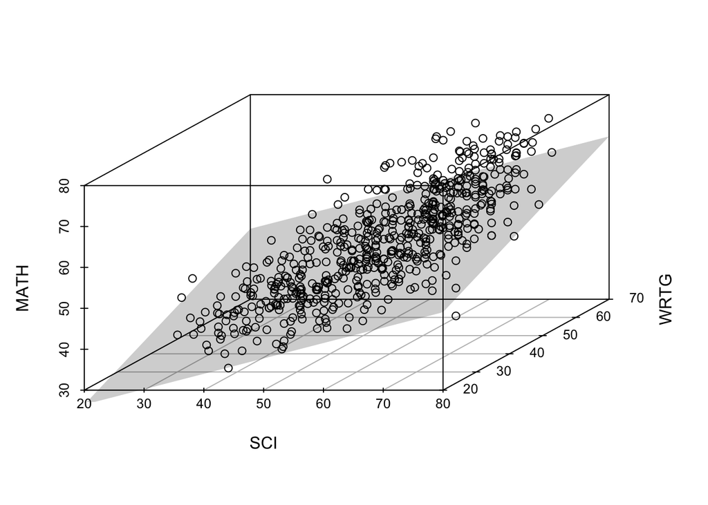

Este plano podemos representarlo así:

$$Y= 10.6285904 + 0.3765304 \cdot WRTG + 0.4152733 \cdot SCI + \epsilon$$

Es clave darse cuenta de otro detalle, que el coeficiente de WRTG ha variado en la fórmula ahora que está presente SCI ¿Por qué sucede esto? Veamoslo así: en el primer caso, WRTG y $\epsilon$ buscaban representar la variabilidad en MATH, y ahora, en el segundo caso, viene SCI para mejorar esa explicación; es así que el peso de la explicación ahora se recalcula y el coeficiente de WRTG deja de explicar lo que le corresponde a SCI, y también le entrega *algo* a SCI.

Como no tiene coeficiente, representamos su variación usando el error típico de los residuos o *residual standard error* (RSE). Nótese que éste ha variado de un modelo ha otro, ahora tenemos un RSE menor. Aquí vale la pena preguntarse si esta disminución del error es significativa, obteniendo:

**Table de Análisis de Varianza**

|  | Res.Df | RSS | Df | Sum of Sq | F | Pr(> F) |
| --- | --- | --- | --- | --- | --- | --- |
| 1 | 598 | 31,842.070 |  |  |  |  |
| 2 | 597 | 25,262.730 | 1 | 6,579.335 | 155.481 | 0 |

La comparación de modelos usando la tabla de análisis de varianza (anova) propone como hipótesis nula que los modelos no difieren (no se ha reducido el error al pasar de un modelo a otro). Como la comparación es *significativa* (vea el **P**), rechazamos igualdad de modelos: el modelo 2 sí reduce el error al incluir una variable más.

Finalmente, veamos el rol de sexo:

|  | *Dependent variable:* |
| --- | --- |
|  | MATH |
| Constant | 11.306*** |
|  | (1.630) |
| WRTG | 0.424*** |
|  | (0.036) |
| SCI | 0.375*** |
|  | (0.035) |
| SEXFemale | -1.922*** |
|  | (0.582) |
| Observations | 600 |
| R<sup>2</sup> | 0.533 |
| Adjusted R<sup>2</sup> | 0.530 |
| Residual Std. Error | 6.452 (df = 596) |
| F Statistic | 226.510*** (df = 3; 596) |
| *Note:* | p<0.1; p<0.05; p<0.01 |

Aunque no podemos graficar cuatro coordenadas, podemos usar elementos visuales:

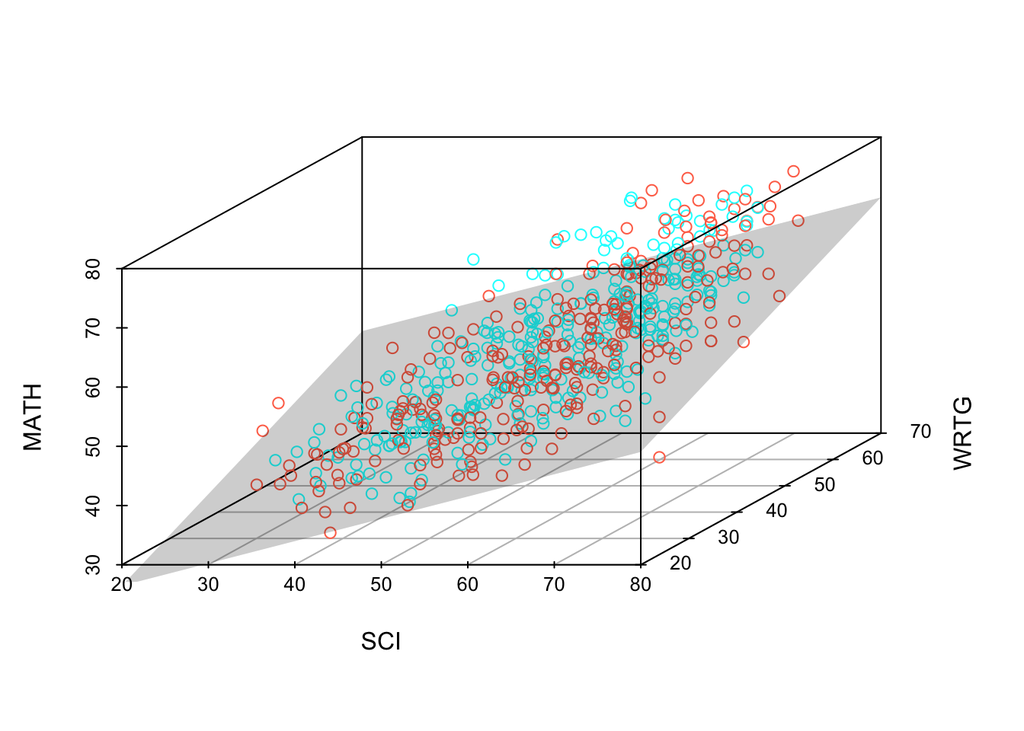

Nuestra nueva ecuación sería:

$$Y= 11.306349 + 0.4235786 \cdot WRTG + 0.3748025 \cdot SCI + -1.9219692 \cdot SEX + \epsilon$$

Nuevamente podemos ver si añadir SEXO en este modelo representa una mejora al anterior:

**Table de Análisis de Varianza**

|  | Res.Df | RSS | Df | Sum of Sq | F | Pr(> F) |
| --- | --- | --- | --- | --- | --- | --- |
| 1 | 598 | 31,842.070 |  |  |  |  |
| 2 | 597 | 25,262.730 | 1 | 6,579.335 | 158.063 | 0 |
| 3 | 596 | 24,808.420 | 1 | 454.308 | 10.914 | 0.001 |

Finalmente, podemos resumir todo en esta tabla:

**Modelos planteadas**

|  | Variable dependiente: |  |  |
| --- | --- | --- | --- |
|  | Desempeño en Matemáticas |  |  |
|  | (1) | (2) | (3) |
| Constante | 19.77*** | 10.63*** | 11.31*** |
|  | (1.63) | (1.63) | (1.63) |
| Desempeño en Escritura | 0.61*** | 0.38*** | 0.42*** |
|  | (0.03) | (0.03) | (0.04) |
| Desempeño en Ciencias |  | 0.42*** | 0.37*** |
|  |  | (0.03) | (0.04) |
| SEXO (mujer) |  |  | -1.92*** |
|  |  |  | (0.58) |
| Observations | 600 | 600 | 600 |
| Adjusted R<sup>2</sup> | 0.40 | 0.52 | 0.53 |
| Residual Std. Error | 7.30 | 6.51 | 6.45 |
| Notas: | p<0.1; p<0.05; p<0.01 |  |  |

al INICIO

[VOLVER A CONTENIDOS](https://politicaygobiernopucp.github.io/estadistica_anapol2/)